# Final_project

Tianxiang Chen, Xuanchen Ren, Yuqiao Liu

2/28/2022

The dataset source: https://www.kaggle.com/vardhansiramdasu/income Kaggle, Income Classification, by Vardhan Siramdasu

```r
library(tidyverse)
library(ISLR)
library(glmnet)
library(tree)
library(maptree)
library(randomForest)
library(gbm)
library(ROCR)
library(caret)
library(leaps)
```

# 1 Introduction

What is subsidies?

A subsidy is a benefit given to a person, business or institution, usually by the government. It can be direct (such as a cash payment) or indirect (such as a tax break). A subsidy is usually intended to eliminate some type of burden, it is usually considered to be in the overall public interest, and it is intended to promote a social good or economic policy.

Why it’s important to have subsidies nowadays?

Subsidies are incentives given by the government to individuals or businesses in the form of cash, grants or tax breaks to improve the availability of certain goods and services and the financial crisis of individuals. With subsidies, consumers are able to address their own personal financial difficulties. With the impact of the epidemic on the world economy in the last two years, more and more people have lost their jobs. That’s why government subsidies are especially important in this situation.

Why it is important to issue the correct subsidy to those who are eligible?

For an employee, the amount of salary determines the quality of his life. For those who are not well paid, it is necessary for the government to issue subsidies. But money is not unlimited, and the government needs to predict how many people will need the subsidy. Therefore, this project is to predict whether an employee needs a subsidy or not.

# 2 Import Data

*Import the csv to R*

```r
income <- read_csv("C:/Users/Tation'chan/Desktop/pstat131/Final project/income.csv")
#View(income)
```

# 3 Data Cleaning

## 3.1 Compute and Delete Missing Value

show how many missing value in csv *and delete remove all rows with NA values*

```r
sum(is.na(income))
```

```
## [1] 3625
```

```r
income<-na.omit(income)
```

Here total 3625 missing value in the csv. Here we known that total 3625 missing value in the csv. We then create New Colume need_subsidy- “Yes” if a person’s salary is less than or equal to 50,000, and “No” otherwise.

## 3.2 Create New Colume need_subsidy

New define a new factor response variable need_subsidy which is “Yes” if a person’s salary is less than or equal to 50,000, and “No” otherwise.

```r
income<-income %>% mutate(need_subsidy=as.factor(ifelse(SalStat=="less than or equal to 50,000","YES", "NO")))
```

## 3.3 Removing SalStat

Before we start to fit model we have to remove the SalStat since this variable is overlap with need_subsidy variable.

```r
income <-income %>% select(-c(SalStat))
```

## 3.4 Creating Training and Test Data Set

Now We have to split the data into the training and test set

```r
train = sample(nrow(income), nrow(income)/2)
dat.train = income[train, ]
# The rest as test data
dat.test = income[-train, ]
```

# 4 Exploratory Data Analysis

## 4.1 Data Summery

```r
summary(income)
```

```
##       age          JobType             EdType          maritalstatus
##  Min.   :17.00   Length:30162       Length:30162       Length:30162
##  1st Qu.:28.00   Class :character   Class :character   Class :character
##  Median :37.00   Mode  :character   Mode  :character   Mode  :character
##  Mean   :38.44
##  3rd Qu.:47.00
##  Max.   :90.00
##   occupation        relationship           race              gender
##  Length:30162       Length:30162       Length:30162       Length:30162
##  Class :character   Class :character   Class :character   Class :character
##  Mode  :character   Mode  :character   Mode  :character   Mode  :character
##
##
##
##   capitalgain     capitalloss       hoursperweek   nativecountry
##  Min.   :    0   Min.   :   0.00   Min.   : 1.00   Length:30162
##  1st Qu.:    0   1st Qu.:   0.00   1st Qu.:40.00   Class :character
##  Median :    0   Median :   0.00   Median :40.00   Mode  :character
##  Mean   : 1092   Mean   :  88.37   Mean   :40.93
##  3rd Qu.:    0   3rd Qu.:   0.00   3rd Qu.:45.00
##  Max.   :99999   Max.   :4356.00   Max.   :99.00
##  need_subsidy
##  NO : 7508
##  YES:22654
##
##
##
##
```

Due to the random distribution of the data, and the fact that many of the variables are not numerical variables. It is difficult for us to find useful information from the summary.

## 4.2 Barplot for Numeric Variables

Here we create some barplot for some numeric variable from the dataset.

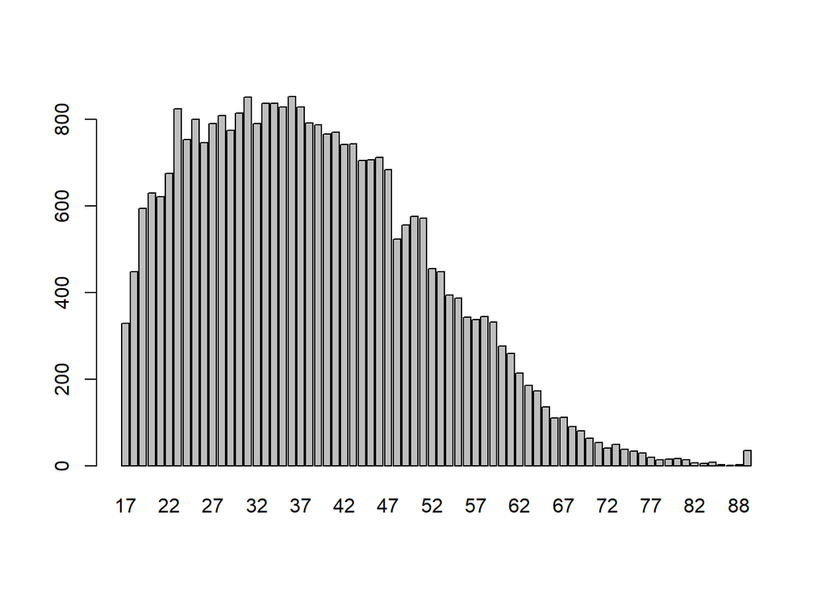

```r
barplot(table(income$age))
```

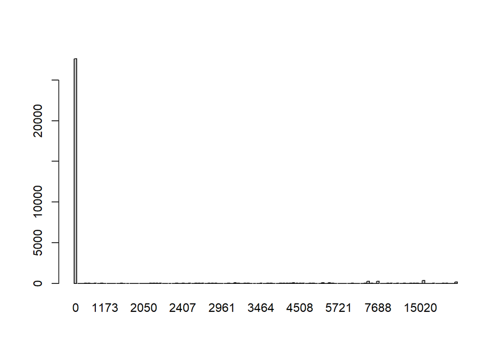

```r
barplot(table(income$capitalgain))
```

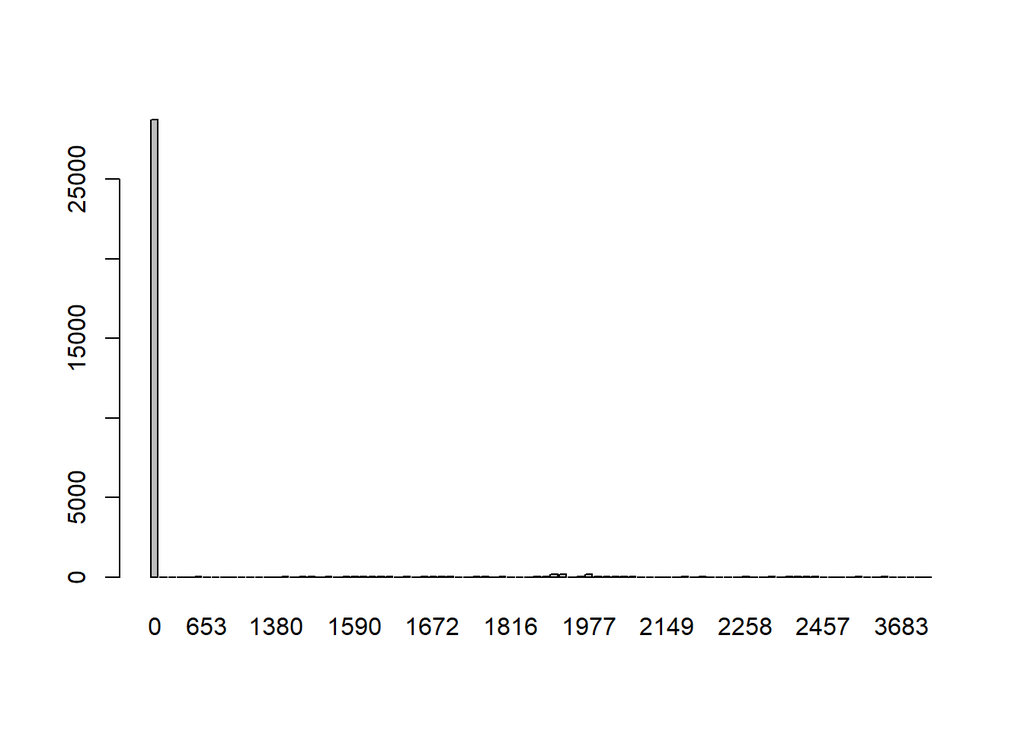

```r
barplot(table(income$capitalloss))
```

Capital gains and losses are hard to tell anything from the graph, so we have to combine it with the correlation plot that follows.

## 4.3 Correlation Summary and Plot

We select the numeric variables to fit in correlation summary and plot which are age, capitalgain, capitalloss,working hours.

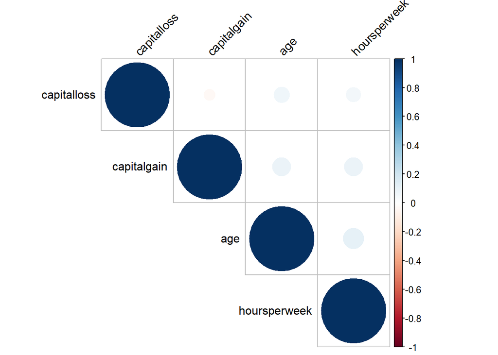

```r
income.1 <- income[, c(1,9,10,11)]

income.cor <- cor(income.1)
library(corrplot)
corrplot(income.cor, type = "upper", order = "hclust",
         tl.col = "black", tl.srt = 45)
```

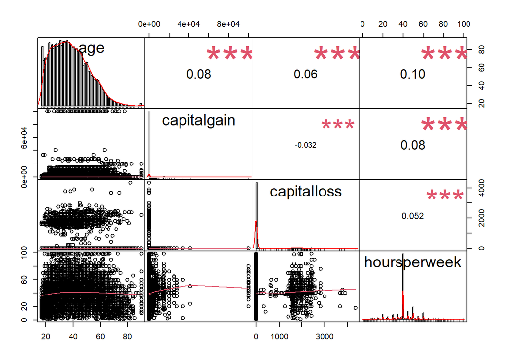

```r
library("PerformanceAnalytics")
chart.Correlation(income.1, histogram=TRUE, pch=19)
```

# 5 Build Models

## 5.1 Decision Tree

Now we will Construct a single decision tree to predict need_subsidy using all other predictors in the training data.

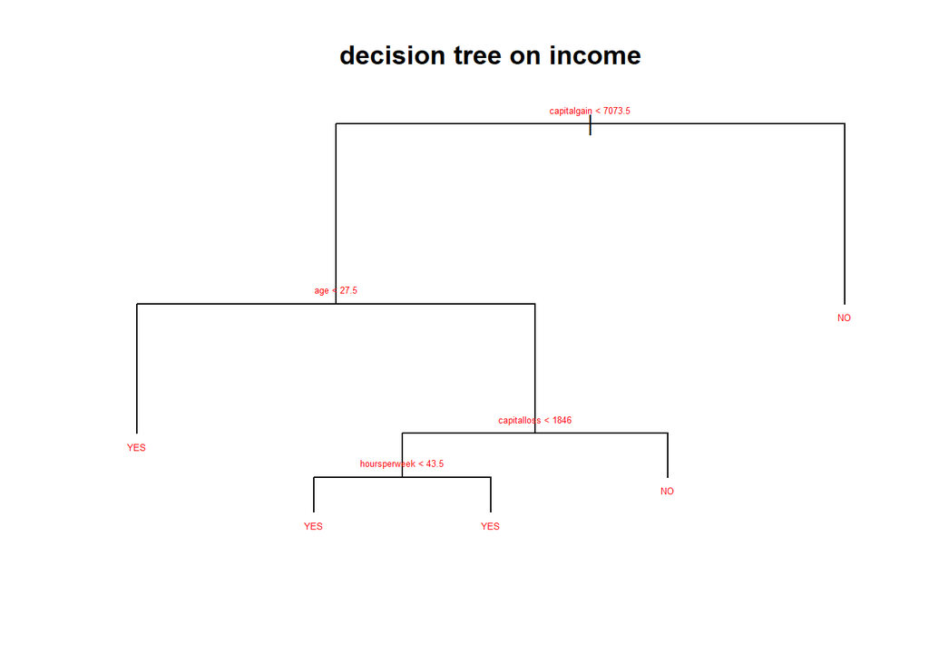

```r
#fit the decision tree
tree.income<-tree(need_subsidy~.,data = dat.train)
#Visualize the tree
plot(tree.income)
text(tree.income, pretty = 0, cex = .4, col = "red")
title("decision tree on income", cex = 0.8)
```

### 5.1.1 Using Cross Validation to Obtain the Optimize Size for Tree

Now this is the decision tree without prune let find the best size of tree by cross validation

```r
#use 5-th cv to determine the best size tree.
# Set random seed
set.seed(3)
# K-Fold cross validation
cv = cv.tree(tree.income, FUN=prune.misclass, K=5)
#best size
best.cv = min(cv$size[cv$dev == min(cv$dev)])
best.cv
```

```
## [1] 4
```

Here the result show that the best size from cross validation is four

### 5.1.2 Now we will prume the original tree to size 4

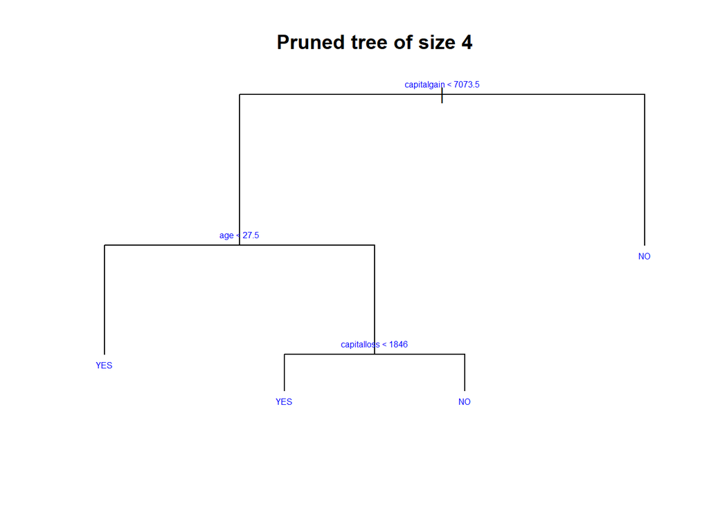

```r
# Prune tree.subdrug
pt.cv = prune.misclass (tree.income, best=best.cv)
# Plot pruned tree
plot(pt.cv)
text(pt.cv, pretty=0, col = "blue", cex = .5)
title("Pruned tree of size 4")
```

### 5.1.3 get the tpr from decision tree

```r
# Predict on tpr
pred.pt.cv = predict(pt.cv,dat.test, type="class")
# Obtain confusion matrix
err.pt.cv = table(pred.pt.cv,dat.test$need_subsidy)
err.pt.cv
```

```
##
## pred.pt.cv    NO   YES
##        NO    974   106
##        YES  2763 11238
```

```r
#The tpr
err.pt.cv[1,1]/sum(err.pt.cv[,1])
```

```
## [1] 0.2606369
```

## 5.2 Using the Regularized Regression Methods

Now we use the regularized regression methods to predict the income and get the test error. For this part we will use ridge regression model & lasso regression model First we have to find the the optimal value of tuning parameter lambda using cross validation

```r
#split the data
set.seed(123)
x=model.matrix(need_subsidy~.,data =income)[,-1]
y=income$need_subsidy
train = sample(nrow(income), nrow(income)/2)
test=(-train)
x.train=x[train,]
y.train=y[train]
x.test=x[test,]
y.test=y[test]
```

### 5.2.1 Fit the Ridge Model

```r
lambda.list.ridge = 1000 * exp(seq(0, log(1e-5), length = 100))
ridge_mod = glmnet(x.train, y.train, alpha = 0, lambda = lambda.list.ridge,family = "binomial")
cv.out.ridge=cv.glmnet(x.train, y.train, alpha = 0,folds=5,family = "binomial")
bestlam = cv.out.ridge$lambda.min
bestlam
```

```
## [1] 0.01900023
```

```r
ridge.pred=predict(ridge_mod,s=bestlam ,newx=x.test,type = "response")
# Save the predicted labels using 0.5 as a threshold
predsubsidy=as.factor(ifelse(ridge.pred<=0.5, "No", "Yes"))
```

#### 5.2.1.1 Confusion matrix (training error/accuracy)

```r
error<-table(pred=predsubsidy, true=dat.test$need_subsidy)
#test error
1-sum(diag(error))/(sum(error))
```

```
## [1] 0.3455341
```

```r
x=model.matrix(need_subsidy~.,data =income)[,-1]
y=income$need_subsidy
out = glmnet(x,y,alpha=0,family = "binomial")
predict(out,type="coefficients",s=bestlam)
```

```
## 95 x 1 sparse Matrix of class "dgCMatrix"
##                                                    s1
## (Intercept)                              4.3675156453
## age                                     -0.0206968870
## JobTypeLocal-gov                         0.2437019105
## JobTypePrivate                           0.1330695540
## JobTypeSelf-emp-inc                     -0.1341827454
## JobTypeSelf-emp-not-inc                  0.4795881083
## JobTypeState-gov                         0.3555443807
## JobTypeWithout-pay                       1.9474682805
## EdType11th                               0.6596324555
## EdType12th                               0.4163574477
## EdType1st-4th                            0.9484616626
## EdType5th-6th                            0.9549702992
## EdType7th-8th                            1.1435995622
## EdType9th                                0.9462365161
## EdTypeAssoc-acdm                        -0.2153345714
## EdTypeAssoc-voc                         -0.2199252239
## EdTypeBachelors                         -0.7571604454
## EdTypeDoctorate                         -1.5708107833
## EdTypeHS-grad                            0.2097577613
## EdTypeMasters                           -1.0640685634
## EdTypePreschool                          1.4950754055
## EdTypeProf-school                       -1.4910255060
## EdTypeSome-college                      -0.0690766092
## maritalstatusMarried-AF-spouse          -1.5424565788
## maritalstatusMarried-civ-spouse         -1.0186720240
## maritalstatusMarried-spouse-absent       0.1580629729
## maritalstatusNever-married               0.5600479340
## maritalstatusSeparated                   0.2485573158
## maritalstatusWidowed                     0.0630459061
## occupationArmed-Forces                   0.6318134476
## occupationCraft-repair                   0.0264406308
## occupationExec-managerial               -0.6935045484
## occupationFarming-fishing                0.8325038584
## occupationHandlers-cleaners              0.6261303879
## occupationMachine-op-inspct              0.3300462086
## occupationOther-service                  0.6906417701
## occupationPriv-house-serv                0.9757256053
## occupationProf-specialty                -0.4791254574
```

[output cut: 42 more lines]

```
## nativecountryNicaragua                   0.5423743089
## nativecountryOutlying-US(Guam-USVI-etc)  1.5590614374
## nativecountryPeru                        0.6499859783
## nativecountryPhilippines                -0.2949861091
## nativecountryPoland                      0.0314311574
## nativecountryPortugal                    0.1923806293
## nativecountryPuerto-Rico                 0.2526149995
## nativecountryScotland                    0.3197405539
## nativecountrySouth                       0.8766179098
## nativecountryTaiwan                      0.1192978128
## nativecountryThailand                    0.5303307533
## nativecountryTrinadad&Tobago             0.4153249655
## nativecountryUnited-States              -0.1547353092
## nativecountryVietnam                     0.7848560007
## nativecountryYugoslavia                 -0.4986646147
```

The test error of ridge model is 0.34

From the table of coefficient of ridge we can some result list below.  
1.age don’t really effect that people need subsidy or not.  
2.People who work without pay more likely need subsidy.  
3.People have lower graducated level more likely need subsidy.  
4.People never married before more likely need subsidy.  
5.People who are work for Private house server industry more likely need subsidy.  
6.race except Asian, black white arer more likely need subsidy.  
7.People who own a child more likely need subsidy.  
8.Gender don’t have positive relation with need_subsidy or not.  
9.people who from developing country are more likely need subsidy. 10.summary the variable above we find the the jobtype-without pay have more closed relation with need_subsidy or not

### 5.2.2 Fit the Lasso Regession

```r
lambda.list.lasso = 2 * exp(seq(0, log(1e-4), length = 100))
lasso.mod <- glmnet(x.train, y.train, alpha=1, lambda = lambda.list.ridge,family = "binomial")
set.seed(1)
cv.out.lasso = cv.glmnet(x.train, y.train, alpha = 1,family = "binomial")
bestlam = cv.out.lasso$lambda.min
lasso.pred = predict(lasso.mod, s = bestlam, newx =x.test,type = "response")
predsubsidy=as.factor(ifelse(lasso.pred<=0.5, "No", "Yes"))
# Confusion matrix (training error/accuracy)
lasso_error<-table(pred=predsubsidy, true=dat.test$need_subsidy)
#test error
1-sum(diag(lasso_error))/(sum(lasso_error))
```

```
## [1] 0.3361846
```

```r
out=glmnet(x,y,alpha=1,lambda=lambda.list.ridge,family = "binomial")
lasso.coef=predict(out,type="coefficients",s=bestlam)
lasso.coef
```

```
## 95 x 1 sparse Matrix of class "dgCMatrix"
##                                                    s1
## (Intercept)                              4.4498971447
## age                                     -0.0169432349
## JobTypeLocal-gov                         .
## JobTypePrivate                           .
## JobTypeSelf-emp-inc                     -0.1102492214
## JobTypeSelf-emp-not-inc                  0.1226546456
## JobTypeState-gov                         .
## JobTypeWithout-pay                       .
## EdType11th                               0.1701359280
## EdType12th                               .
## EdType1st-4th                            .
## EdType5th-6th                            0.1159401319
## EdType7th-8th                            0.6443271055
## EdType9th                                0.2882474832
## EdTypeAssoc-acdm                         .
## EdTypeAssoc-voc                          .
## EdTypeBachelors                         -0.7298512701
## EdTypeDoctorate                         -1.1634611717
## EdTypeHS-grad                            0.1322515698
## EdTypeMasters                           -0.9368823834
## EdTypePreschool                          .
## EdTypeProf-school                       -1.1792635509
## EdTypeSome-college                       .
## maritalstatusMarried-AF-spouse          -0.0348460416
## maritalstatusMarried-civ-spouse         -1.8121921873
## maritalstatusMarried-spouse-absent       .
## maritalstatusNever-married               0.2015954526
## maritalstatusSeparated                   .
## maritalstatusWidowed                     .
## occupationArmed-Forces                   .
## occupationCraft-repair                   .
## occupationExec-managerial               -0.6681630464
## occupationFarming-fishing                0.5829394783
## occupationHandlers-cleaners              0.2277045976
## occupationMachine-op-inspct              0.1244196537
## occupationOther-service                  0.4691988909
## occupationPriv-house-serv                .
## occupationProf-specialty                -0.4417665428
```

[output cut: 42 more lines]

```
## nativecountryNicaragua                   .
## nativecountryOutlying-US(Guam-USVI-etc)  .
## nativecountryPeru                        .
## nativecountryPhilippines                 .
## nativecountryPoland                      .
## nativecountryPortugal                    .
## nativecountryPuerto-Rico                 .
## nativecountryScotland                    .
## nativecountrySouth                       .
## nativecountryTaiwan                      .
## nativecountryThailand                    .
## nativecountryTrinadad&Tobago             .
## nativecountryUnited-States              -0.0213068442
## nativecountryVietnam                     .
## nativecountryYugoslavia                  .
```

From the table of coefficent of lasso regression, we found that no coefficient is shown for some predictor show - because the lasso regression shrunk the coefficient all the way to zero. This means it was completely dropped from the model because it wasn’t influential enough.

## 5.3 construct a random forest model

### 5.3.1 fit the random forest model

Now we will construct a random forest model to predict if subsidy is needed. Firstly we use training data to drain the model.

```r
#fit the random forest model
#View(dat.train)
rf.train=randomForest(need_subsidy~.,data = dat.train,importance=TRUE)
rf.train
```

```
##
## Call:
##  randomForest(formula = need_subsidy ~ ., data = dat.train, importance = TRUE)
##                Type of random forest: classification
##                      Number of trees: 500
## No. of variables tried at each split: 3
##
##         OOB estimate of  error rate: 14.16%
## Confusion matrix:
##       NO   YES class.error
## NO  2325  1446  0.38345267
## YES  689 10621  0.06091954
```

#### 5.3.1.1 predict the result from the model above

After training the model, we will predict on the test data.

```r
#After training the model, predict on the test data.
rf.predict = predict(rf.train, newdata = dat.test)
```

#### 5.3.1.2 Get the confusion matrix

The prediction with the test data is finished, then we are able to build a confusion matrix, to see directly the result. Finally we compute the test error rate, using the data of confusion matrix.

```r
# Confusion matrix
rf.err = table(pred = rf.predict, truth = dat.test$need_subsidy )
#Calculating the test error
test.rf.err = 1 - sum(diag(rf.err))/sum(rf.err)
test.rf.err
```

```
## [1] 0.1423646
```

## 5.4 log regresssion model

### 5.4.1 Fit logistic regression model

```r
# Fit logistic regression model
glm.fit = glm(need_subsidy~.,data = dat.train, family=binomial)
# Summarize the logistic regression model
summary(glm.fit)
```

```
##
## Call:
## glm(formula = need_subsidy ~ ., family = binomial, data = dat.train)
##
## Deviance Residuals:
##     Min       1Q   Median       3Q      Max
## -3.6215   0.0000   0.1803   0.5094   5.0444
##
## Coefficients:
##                                           Estimate Std. Error z value Pr(>|z|)
## (Intercept)                              7.778e+00  1.105e+00   7.041 1.90e-12
## age                                     -2.588e-02  2.431e-03 -10.648  < 2e-16
## JobTypeLocal-gov                         7.188e-01  1.621e-01   4.434 9.23e-06
## JobTypePrivate                           5.624e-01  1.344e-01   4.184 2.87e-05
## JobTypeSelf-emp-inc                      4.254e-01  1.755e-01   2.424 0.015367
## JobTypeSelf-emp-not-inc                  1.096e+00  1.566e-01   7.001 2.54e-12
## JobTypeState-gov                         9.120e-01  1.792e-01   5.088 3.62e-07
## JobTypeWithout-pay                       1.458e+01  7.537e+02   0.019 0.984570
## EdType11th                              -1.074e-01  3.015e-01  -0.356 0.721693
## EdType12th                              -6.047e-01  3.970e-01  -1.523 0.127695
## EdType1st-4th                            1.526e-01  6.644e-01   0.230 0.818296
## EdType5th-6th                            1.327e-01  4.659e-01   0.285 0.775741
## EdType7th-8th                            7.464e-01  3.517e-01   2.122 0.033802
## EdType9th                                5.325e-01  4.067e-01   1.309 0.190427
## EdTypeAssoc-acdm                        -1.242e+00  2.535e-01  -4.898 9.66e-07
## EdTypeAssoc-voc                         -1.328e+00  2.416e-01  -5.498 3.83e-08
## EdTypeBachelors                         -1.921e+00  2.245e-01  -8.559  < 2e-16
## EdTypeDoctorate                         -3.195e+00  3.192e-01 -10.009  < 2e-16
## EdTypeHS-grad                           -7.371e-01  2.177e-01  -3.386 0.000710
## EdTypeMasters                           -2.338e+00  2.398e-01  -9.751  < 2e-16
## EdTypePreschool                          2.060e+01  2.755e+02   0.075 0.940394
## EdTypeProf-school                       -3.003e+00  2.928e-01 -10.256  < 2e-16
## EdTypeSome-college                      -1.086e+00  2.214e-01  -4.905 9.36e-07
## maritalstatusMarried-AF-spouse          -4.070e+00  8.388e-01  -4.852 1.22e-06
## maritalstatusMarried-civ-spouse         -2.304e+00  3.701e-01  -6.227 4.75e-10
## maritalstatusMarried-spouse-absent       2.211e-03  3.484e-01   0.006 0.994935
## maritalstatusNever-married               4.641e-01  1.281e-01   3.624 0.000291
## maritalstatusSeparated                   1.497e-01  2.447e-01   0.612 0.540608
## maritalstatusWidowed                    -1.235e-01  2.231e-01  -0.553 0.579922
## occupationArmed-Forces                   1.316e+01  5.898e+02   0.022 0.982193
```

[output cut: 154 more lines]

```
## nativecountryThailand
## nativecountryTrinadad&Tobago
## nativecountryUnited-States
## nativecountryVietnam
## nativecountryYugoslavia                 .
## ---
## Signif. codes:  0 '***' 0.001 '**' 0.01 '*' 0.05 '.' 0.1 ' ' 1
##
## (Dispersion parameter for binomial family taken to be 1)
##
##     Null deviance: 16962.8  on 15080  degrees of freedom
## Residual deviance:  9679.5  on 14987  degrees of freedom
## AIC: 9867.5
##
## Number of Fisher Scoring iterations: 14
```

Here we can set up a hypothesis for each predictor Xi that H0:The predictor Xi are related to response H1:The predictor xi are not related to response where i in 0 to n

So the from the table above we get the p-value for each predictor xi if the p-value is less than 0.05 then we reject the null hypothesis and this predictor wasn’t influential enough for the response.The predictor list below are less than 0.05

For the variable Edtype we find that people who have the high level education are not need subsidy since those variable are less than 0.05

For the marital status we find that people were married are not need subsidy since those variable less than 0.05.

For the race we find that white and Asian are not need subsidy since those variable less than 0.05.

For the country we find that the person who from east asian, west euro,North and middle amrican are not need subsidy since those variable less than 0.05.

### 5.4.2 Construct confusion matrix for the training data

```r
prob.training = predict(glm.fit, type="response")
#round(prob.training, digits=2)
# Save the predicted labels using 0.5 as a threshold
dat.train = dat.train %>%
  mutate(pred.need_subsidy=as.factor(ifelse(prob.training<=0.5, "No", "Yes")))
# Confusion matrix (training error/accuracy)
log_error = table(pred=dat.train$pred.need_subsidy, true=dat.train$need_subsidy)
log_error
```

[output not shown]

### 5.4.3 Construct ROC curve and compute AUC to determind how the model fits.

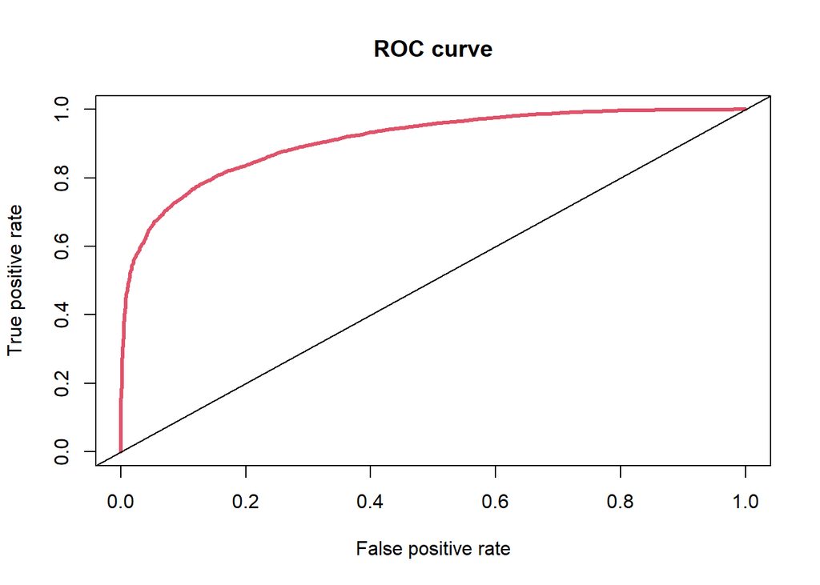

```r
library(ROCR)
# First arument is the prob.training, second is true labels
pred = prediction(prob.training, dat.train$need_subsidy)
# TPR on the y axis and FPR on the x axis
perf = performance(pred, measure="tpr", x.measure="fpr")
plot(perf, col=2, lwd=3, main="ROC curve")
abline(0,1)
```

```r
# Calculate AUC
auc = performance(pred, "auc")@y.values
auc
```

```
## [[1]]
## [1] 0.9091677
```

# 6 Compare the performance of each models

To choose the best model, we will calculate the TPR and FPR for each model. TPR=TP/(TP+FN), and FPR=FN/(FP+TN)

## 6.1 copy the confusion matrix and test error for random forest

We firstly copy the confusion matrix and test error for random forest

```r
rf.err = table(pred = rf.predict, truth = dat.test$need_subsidy )
#Calculating the test error
test.rf.err = 1 - sum(diag(rf.err))/sum(rf.err)
test.rf.err
```

```
## [1] 0.1423646
```

```r
#TPR=94%
rf.err[2,2]/sum(rf.err[,2])
```

```
## [1] 0.9430536
```

```r
#FPR=18%
(rf.err[1,2])/(sum(rf.err[,1]))
```

```
## [1] 0.1728659
```

## 6.2 Confusion matrix and test error for logistic regression

Confusion matrix and test error for logistic regression

```r
log_erorr = table(pred=dat.train$pred.need_subsidy, true=dat.train$need_subsidy)
log_error
```

```
##      true
## pred     NO   YES
##   No   2314   828
##   Yes  1457 10482
```

```r
#test error
1-1-sum(diag(log_error))/(sum(log_error))
```

```
## [1] -0.8484848
```

```r
#TPR=93%
log_error[2,2]/sum(log_error[,2])
```

```
## [1] 0.9267905
```

```r
#FPR=21%
(log_error[1,2])/(sum(log_error[,1]))
```

```
## [1] 0.2195704
```

Then we found out the TPR is about 93%, and the FPR is 21%

## 6.3 confusion matrix and test error for lasso regression

```r
lasso_error = table(pred=predsubsidy, true=dat.test$need_subsidy)
lasso_error
```

```
##      true
## pred    NO  YES
##   No   663 1996
##   Yes 3074 9348
```

```r
#test error
1-sum(diag(lasso_error))/(sum(lasso_error))
```

```
## [1] 0.3361846
```

```r
#TPR=82%
lasso_error[2,2]/sum(lasso_error[,2])
```

```
## [1] 0.824048
```

```r
#FPR=53%
(lasso_error[1,2])/(sum(lasso_error[,1]))
```

```
## [1] 0.5341183
```

Then we found out that the TPR is 82%, the FPR is 53%

```r
error = table(pred=predsubsidy, true=dat.test$need_subsidy)
error
```

```
##      true
## pred    NO  YES
##   No   663 1996
##   Yes 3074 9348
```

```r
#test error
1-sum(diag(error))/(sum(error))
```

```
## [1] 0.3361846
```

```r
#TPR=82%
error[2,2]/sum(error[,2])
```

```
## [1] 0.824048
```

```r
#FPR=53%
(error[1,2])/(sum(error[,1]))
```

```
## [1] 0.5341183
```

## 6.5 Confusion matrix and test error for decision tree model

```r
err.pt.cv = table(pred.pt.cv,dat.test$need_subsidy)
err.pt.cv
```

```
##
## pred.pt.cv    NO   YES
##        NO    974   106
##        YES  2763 11238
```

```r
#The test error
test_error<-1-sum(diag(err.pt.cv))/sum(err.pt.cv)
test_error
```

```
## [1] 0.1902394
```

```r
#TPR=99%
err.pt.cv[2,2]/sum(err.pt.cv[,2])
```

```
## [1] 0.9906559
```

```r
#FPR=3%
(err.pt.cv[1,2])/(sum(err.pt.cv[,1]))
```

```
## [1] 0.028365
```

Then we found out the TPR is 99%, and the FPR is 3%. According to the TPR and FPR value of all the model we use, we get the highest TPR and lowest FPR in Decision Tree model. So the Decision Tree model is the best model for our project.

# 7 Conlusion

In this final project, we also experienced some difficulties and made progress

## 7.1 Key Finding

### 7.1.1 key Finding 1

1.After we builed models associated with data set, we compare the test error initially. However, It is hard to gain the comparable test error for log regreesion model. Then after reaserching, we decided to compare TPR and FPR of each models. Then we get the final result.

### 7.1.2 key Finding 2:

2.TPR is important because it is about how credible the model we choose is. If the TPR is high enough, the government will need less money as reserve funds. And the FPR is important because it is about how much reserve funds the government can expect to set aside when adopting our model. This will allow the government to plan its finances more accurately.